# **RNA-Seq Data Visualization & Analysis in R**

Matt Maxwell

April 18, 2023

### **RNA-seq analysis pipeline**

The RNA-seq analysis pipeline utilized in this vignette is represented in the following flowchart. The pipeline sections colored in gray were performed using bash shell scripting and the HOMER bioinformatics suite on the Salk Institute Integrative Genomics & Bioinformatics and will not be covered here. The pipeline sections highlighted in pink are performed in Rstudio and are covered in depth here including the R code and resulting outputs.

[interactive chart not shown]

### **Import data & load packages**

The data visualized & analyzed here is from an RNA-seq experiment comparing the transcriptomes of MC38 mouse colon cancer cells genetically engineered with CRISPR-Cas9 to be deficient in the ARID1A tumor suppressor gene (sg*Arid1a*) versus CRISPR control MC38 cells that are *Arid1a* wildtype (sgScramble). The `edgeR_df` dataframe from this experiment includes important data such as normalized mRNA transcript counts, Log2fc, and adjusted p values across the transcriptome.

```r
#To set working directory on windows machine, replace backslashes with double backslashes for R to accept our file path
wd <- r"(C:\Users\mattm\OneDrive\Desktop\Hargreaves_Lab\MC38_data\RNA_seq\ggplot_Volcano)"

#set working directory
setwd(wd)

#set this as our working directory for all code chunks, not just this one.
knitr::opts_chunk$set(root.dir = wd)

#Set preference for no warnings to be given when running code chunks in R markdown
knitr::opts_chunk$set(warning = FALSE, message = FALSE)

#read in our dataframe
edgeR_df <- read.delim("sgArid1a_MC38_edgeR.txt", header = TRUE, sep = "\t")

#load packages with package manager package called pacman
if (!require("pacman")) install.packages("pacman")
pacman::p_load(here,
               tidyverse, #dyplyr and ggplot utilities
               scales, # Transform axis scales
               ggrepel, # Optimize plot label separation
               ComplexHeatmap, #Awesome heatmap package
               viridis, #Package for some of my favorite color palettes like Magma
               RColorBrewer,#Package for some of my favorite color palettes like Magma
               forcats,
               ggstance,
               enrichplot,
               msigdbr, #Molecular signatures database package for GSEA
               clusterProfiler) #Package for GSEA dotplot
```

### **Data wrangling for volcano plot**

```r
#Rename our columns of interest using the rename function in dyplyr from tidyverse package
edgeR_df <- rename(edgeR_df, Gene = Annotation.Divergence, Log2fc = sgArid1a.vs..sgScramble.Log2.Fold.Change, adj_p_value =sgArid1a.vs..sgScramble.adj..p.value)


#Grab the gene name values preceding "|" edgeR from Gene column
edgeR_df$Gene <- sub("\\|.*", "", edgeR_df$Gene)

#grab the columns we need for volcano plot
volcano_df <- edgeR_df[, c("Gene", "Log2fc", "adj_p_value")]


# Replace NA values in Log2FC column with Zero.
volcano_df$Log2fc[is.na(volcano_df$Log2fc)] <- 0


#Define the parameters you want to classify a gene as upregulated, donwregulated, or not significantly changed (NS)
volcano_df <- volcano_df %>%
  mutate(gene_type = case_when(Log2fc >= .585 & adj_p_value <= 0.05 ~ "Upregulated",
                               Log2fc <= -.585 & adj_p_value <= 0.05 ~ "Downregulated",
                               TRUE ~ "NS"))

#Count the number of genes in the three classes we defined
volcano_df %>%
  count(gene_type)
```

```
##       gene_type     n
## 1 Downregulated   218
## 2            NS 24135
## 3   Upregulated   184
```

```r
#Specify colors, sizes, and transparancy values associated with the three classes
cols <- c("Upregulated" = "#ffad73", "Downregulated" = "#26b3ff", "NS" = "grey")
sizes <- c("Upregulated" = 3, "Downregulated" = 3, "NS" = 1)
alphas <- c("Upregulated" = 1, "Downregulated" = 1, "NS" = 0.5)

# Define genes to highlight on the volcano plot
signif_genes <- volcano_df %>%
  filter(Gene %in% c("Tap1", "Cxcl10", "Stat1", "Ptgs1", "Cd47", "Il4ra"))

Up_genes <- volcano_df %>%
  filter(Gene %in% c("Tap1", "Cxcl10", "Stat1"))

Down_genes <- volcano_df %>%
  filter(Gene %in% c("Ptgs1", "Cd47"))
```

### **Volcano plot**

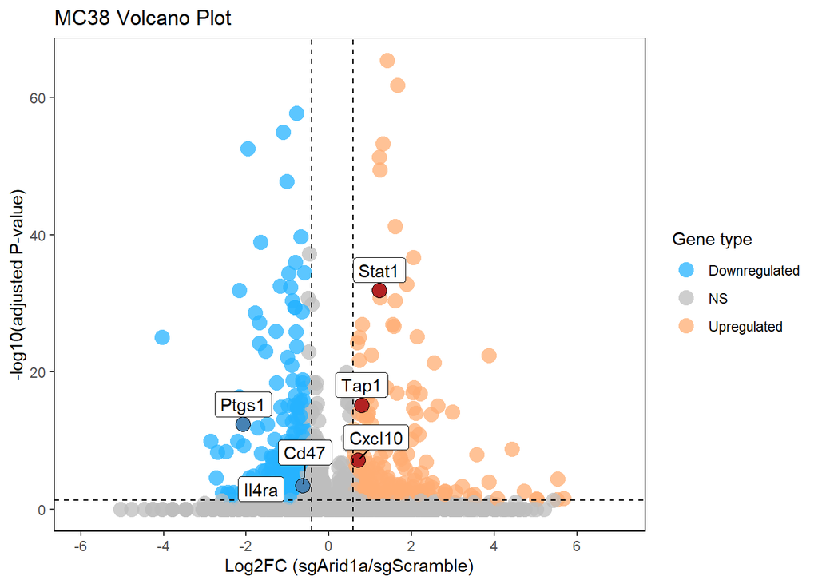

**Figure 1: Volcano plot Highlighting Differentially Expressed Genes in sgArid1a MC38 cells**

```r
#Customize what we want to show in our the volcano plot
final_plot <- ggplot(data = volcano_df,
                     aes(x = Log2fc,
                         y = -log10(adj_p_value))) +
  geom_point(aes(colour = gene_type),
             alpha = .75,
             shape = 16,
             size = 4) +
  geom_point(data = Up_genes,
             shape = 21,
             size = 4,
             fill = "firebrick",
             colour = "black") +
  geom_point(data = Down_genes,
             shape = 21,
             size = 4,
             fill = "steelblue",
             colour = "black") +
  geom_hline(yintercept = -log10(0.05),
             linetype = "dashed") +
  geom_vline(xintercept = c(log2(.75), log2(1.5)),
             linetype = "dashed") +
  geom_label_repel(data = signif_genes,
                   aes(label = Gene),
                   force = 1,
                   nudge_y = 2) +
  scale_colour_manual(values = cols) +
  scale_x_continuous(breaks = c(seq(-6, 7, 2)),
                     limits = c(-6, 7)) +
  labs(title = "MC38 Volcano Plot",
       x = "Log2FC (sgArid1a/sgScramble)",
       y = "-log10(adjusted P-value)",
       colour = "Gene type") +
  theme_bw() + # Select theme with a white background
  theme(panel.border = element_rect(colour = "black", fill = NA, linewidth = 0.5),
        panel.grid.minor = element_blank(),
        panel.grid.major = element_blank())

#Call the volcano plot
final_plot
```

Volcano plots such as this are a great way to visualize pair wise comparisons of the number of genes changing, the magnitude of change, and statistical confidence associated with those changes. It can also be useful when presenting data to highlight genes of interest on our volcano plot such as the three up & downregulated genes I’ve highlighted on this volcano plot. For example, here the genes I’ve highlighted all relate to the process of anti-tumor immunity which is the process I’m studying and thus of value to highlight on the volcano plot to communicate these specific changes.

### **Data wrangling for Heatmap**

```r
#Rename the normalized counts columns we'll need for our heatmap by referencing their column number
edgeR_df <- rename(edgeR_df, sgScr_1 = 9, sgScr_2 = 10, sgArid1a_1 = 11, sgArid1a_2 = 12)

#Filter for significantly up or downregulated genes
#We only want to plot significantly changed genes on this heatmap
edgeR_df2 <- edgeR_df %>%
  filter(Log2fc >= .585 |Log2fc <= -.585, adj_p_value <= .05)

#Grab gene name and edgeR normalized counts for each group
heatmap_df <- edgeR_df2[, c(8:12)]

#Make dataframe without gene column, the first column of the df
heat_mat <- heatmap_df[,-1]

#Assign gene names from 'heatdata' as row names to new dataframe object 'mat'
rownames(heat_mat) <- heatmap_df[,1]

#Convert dataframe to a matrix, can use data.matrix() or as.matrix()
heat_mat <- data.matrix(heat_mat)

#Generate gene Z scores and transpose matrix
heat_mat <- t(scale(t(heat_mat)))

#List of interesting genes we'd like to label on heatmap
heat_anotation <- signif_genes

#add a column for row # in heatmap_df
heatmap_df$rownumber = 1:nrow(heatmap_df)

#Add row number values from heatdata to heat_anotation
heat_anotation <- merge(heat_anotation,heatmap_df, all = F)

#Print row numbers for heat_anotation from heatdata
cat(heat_anotation$rownumber,sep=",")
```

```
## 229,234,215,352,295,16
```

```r
x <- heat_anotation$Gene
x_list <- as.list(x, ",")
print(x_list)
```

```
## [[1]]
## [1] "Cd47"
##
## [[2]]
## [1] "Cxcl10"
##
## [[3]]
## [1] "Il4ra"
##
## [[4]]
## [1] "Ptgs1"
##
## [[5]]
## [1] "Stat1"
##
## [[6]]
## [1] "Tap1"
```

```r
#Create object with row name locations of genes from heatdata that you'd like to annotate on heatmap
genelabels = rowAnnotation(foo = anno_mark(at = c(229,234,215,352,295,16),
                                           labels = x_list))
```

### **Heatmap**

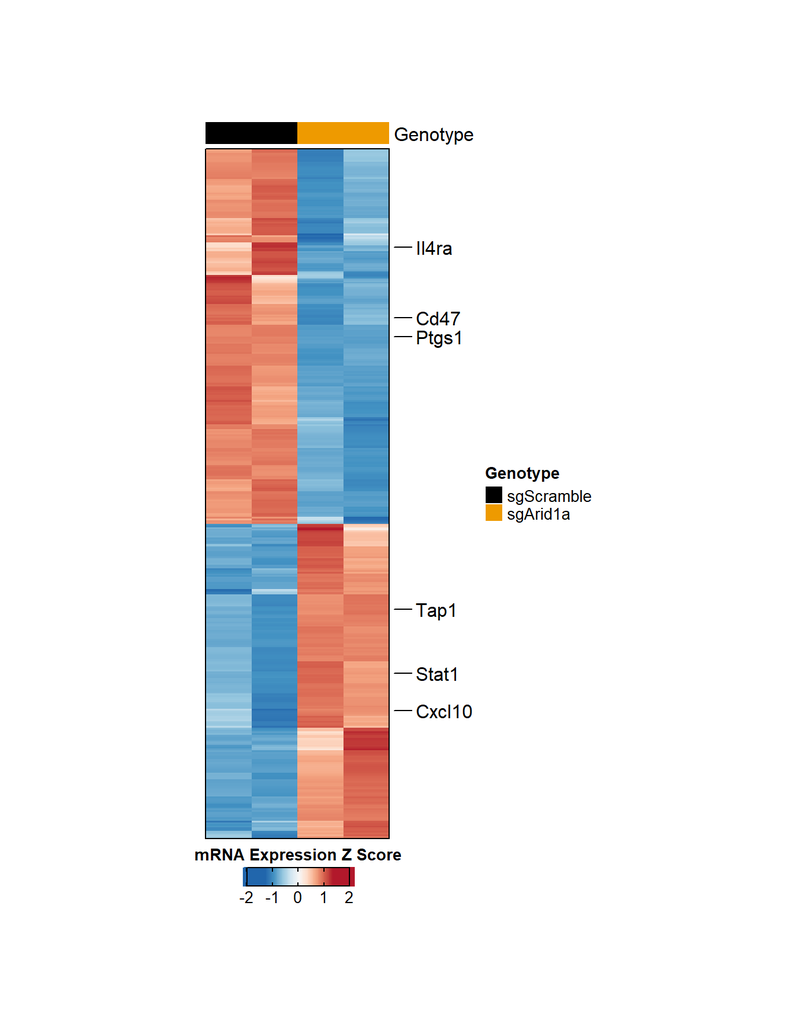

**Figure 2: Heatmap of Differentially Expressed Genes in sgArid1a MC38 cells**

```r
#Define a list of our sample genotypes as a factor of either sgScramble or sgArid1a
fa = factor(c("sgScramble", "sgScramble", "sgArid1a", "sgArid1a"),
            levels = c("sgScramble", "sgArid1a"))

#Define Heatmap annotation color bars for genotype designation
ha = HeatmapAnnotation(Genotype = fa, height = unit(1, "cm"),
                       col = list("Genotype"=c("sgScramble"="black","sgArid1a"="orange2")))

#Passing my fav color palette RdBu to mypalette object
mypalette = rev((brewer.pal(n=9, ("RdBu"))))


ht <- Heatmap(heat_mat, #col = col_fun,
              #col = viridisLite::magma(n = 100),
              col = mypalette,
              top_annotation = ha, heatmap_width = unit(6 , "cm"), heatmap_height = unit(16, "cm"),
              border = TRUE, cluster_rows = T, right_annotation = genelabels,
              show_column_dend = F, show_row_dend = F, show_row_names = F,  column_names_side = "top",
              column_names_rot = 2, show_column_names = F, cluster_columns = F,
              use_raster=T, row_km = 1, raster_quality=5,
              column_names_gp = gpar(fontsize=10),
              heatmap_legend_param = list(height = unit(16, "cm"), direction = "horizontal",
                                          title = "mRNA Expression Z Score", border = "black",
                                          title_position = "topcenter"))
ht_legend_dn <- draw(ht, heatmap_legend_side = "bottom")
```

Heatmaps such as this one are useful for visualizing the relative relationships between gene expression values between samples where rows are individual genes and columns are samples. You can also communicate how many genes are upregulated versus downregulated in relative terms with heatmaps. Here, I’ve highlighted the same six genes I highlighted in the volcano plot that I know are important for the biological process I’m studying, anti-tumor immunity.

### **Data wrangling for GSEA Dotplot**

```r
#Grab gene name, Log2fc, and adj_p_value
GSEA_df <- volcano_df[,1:3]

#Add a column for GSEA values
GSEA_df$GSEA <- -log10(GSEA_df$adj_p_value) * sign(GSEA_df$Log2fc)

#Create object with gene name and GSEA value
geneList <- GSEA_df[,4]
names(geneList) <- as.character(GSEA_df[,1])

#sort the genes in the list according to highest to lowest GSEA value
geneList <- sort(geneList,decreasing=TRUE)

#Lets see the top genes in the list
head(geneList)
```

```
##   Slc5a3    Ifi27    Cotl1    Helz2 Lgals3bp    Oasl2
## 65.46435 61.78099 53.29668 51.30068 49.41965 41.24129
```

```r
#Use msigdbr package to read in the gene sets for GSEA analysis
#msigdbr gives access to many different gene sets
#For example, instead of Hallmarks, could import GO gene sets by specificying category ="C5"
Hallmark <- msigdbr(species = "Mus musculus", category = "H")
Hallmark_v2 = Hallmark %>% dplyr::select(gs_name, gene_symbol) %>% as.data.frame()

#Run GSEA analysis of your gene list against Hallmarks
set.seed(8888)
Gsea_result <- GSEA(geneList, TERM2GENE=Hallmark_v2, verbose=FALSE,
                    pvalueCutoff = .8, pAdjustMethod = "BH", nPerm = 1000)

# Plot only selected gene sets
library(stringr)

## count the gene number for each enrichment
Gene_count<- Gsea_result@result %>% group_by(ID) %>%
  summarise(count = sum(str_count(core_enrichment,"/")) + 1)

## merge with the original dataframe
GSEA_data_frame <- left_join(Gsea_result@result, Gene_count, by = "ID") %>% mutate(GeneRatio = count/setSize)

## for reordering the factor
library(forcats)
Data_activated1 <- GSEA_data_frame %>% filter(NES>0 | NES < 0)

#Take the word Hallmark out of gene sets for plot visualization purposes
Data_activated1$Description <- gsub("_", " ", Data_activated1$Description)
Data_activated1$Description <- str_to_title(Data_activated1$Description)
Data_activated1$Description <- gsub("Hallmark ", "", Data_activated1$Description)


#Arrange gene set df by NES score
Data_activated1 <- arrange(Data_activated1, desc(NES))

#Take the hightest and lowest NES value gene sets
upregulated_gs <- slice_head(Data_activated1, n=5)
downregulated_gs <- slice_tail(Data_activated1, n=5)

#downregulated_gs <- tail(Data_activated1, n=5)
Dotplot_gs <- rbind(upregulated_gs, downregulated_gs)
```

### **GSEA Dotplot**

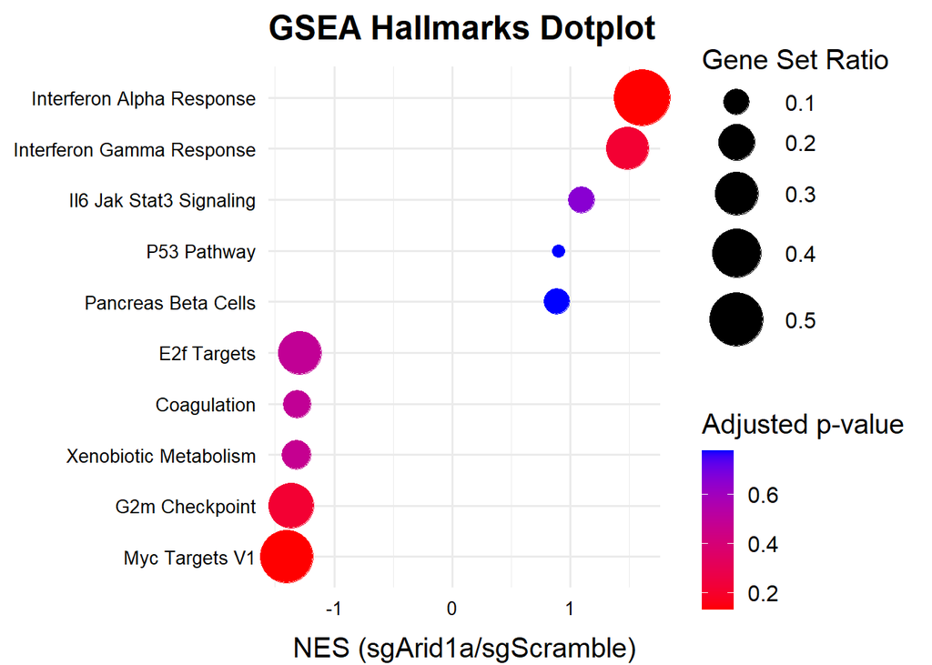

```r
# ggplot(Data_activated1, aes(NES, fct_reorder(Description, NES), fill=Data_activated1$p.adjust), showCategory=5) +
#     geom_col(orientation='y') +
#     scale_fill_continuous(low='red', high='blue', guide=guide_colorbar(reverse=TRUE)) +
#     theme_minimal() + ylab(NULL)

custom_dotplot <- ggplot(Dotplot_gs, aes(NES, fct_reorder(Description, NES))) +
  geom_point(aes(size = GeneRatio, color = p.adjust)) +
  theme_minimal(base_size = 15) +
  #scale_colour_viridis_c(limits = c(5.0e-06, 2.5e-05). direction = 1, option = "viridis")+
  ylab(NULL) +
  #ggtitle("Hallmark enrichment", ) +
  scale_size_continuous(range = c(3, 14)) + scale_colour_gradient(low="red", high = "blue") + coord_cartesian(clip = "off") +
  labs(color="Adjusted p-value", size="Gene Set Ratio") +
  theme(axis.text=element_text(size=10,color="black")) +
  xlab("NES (sgArid1a/sgScramble)") +
  ggtitle(substitute(paste(bold("GSEA Hallmarks Dotplot")))) +
  theme(axis.title.x = element_text(size = 15, angle = 0, vjust = -1))
custom_dotplot
```

RNA-seq analyses such as these have been critical tools in my doctoral work looking to elucidate the molecular consequences of ARID1A tumor suppressor mutation. For example, GSEA analyses such as these that I found that Interferon Alpha Response (Type I Interferon) gene set signature activation is a common consequence of ARID1A mutation across multiple different cancer cell types.